# Tutorial on differential ChIP-Seq analysis using the DiffBind package

# 4 Quality checks and sample visualization

After deriving the count matrix of consensus peaks over all samples, we can now visualize the samples using low dimensional representations. To that end, DiffBind provides functions to create correlation based heatmaps and PCA plots. Both plots can be used to visualize the samples and it is expected that replicates of the same samples and conditions are more similar to each other than to those of different conditions.

## 4.1 PCA plot

The PCA plot in Figure 1 shows that the samples group by cell type, whereby PC1 and PC2 explain 41% and 20% of the variance respectively.

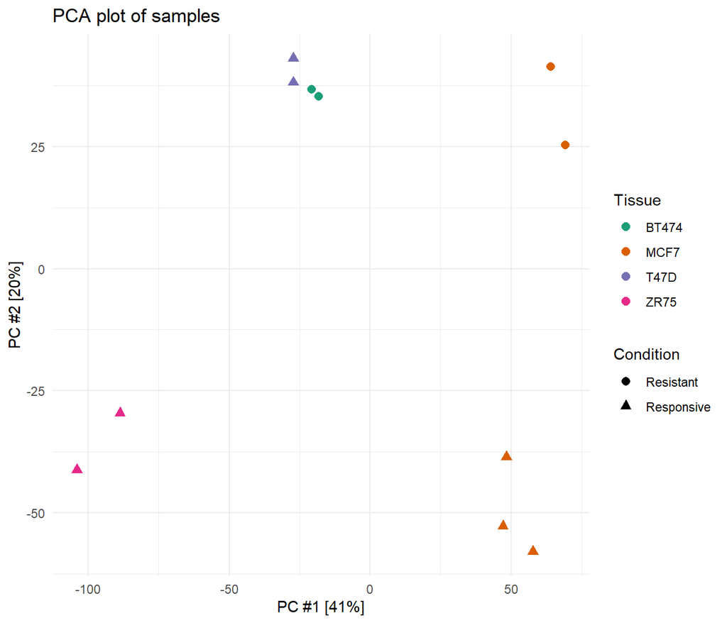

Figure 1: PCA plot

```r
# PCA
pc=DiffBind:::pv.pcmask(tamoxifen)

# Get plotdata PC1, PC2
plotData <- as.data.frame(pc$pc$x[,c("PC1","PC2")])
# Var
vr <- rep(0,length(pc$pc$sdev))
for (i in 1:length(vr)) {
vr[i] <- pc$pc$sdev[i] ^ 2
}

# Var explained
c1p <- vr[1] / sum(vr) * 100
c2p <- vr[2] / sum(vr) * 100

# Add condition
plotData$Condition = tamoxifen$samples[match(rownames(plotData), tamoxifen$samples$SampleID),"Condition"]

# Add tissue
plotData$Tissue = tamoxifen$samples[match(rownames(plotData), tamoxifen$samples$SampleID),"Tissue"]

# plotlabs
xlab=sprintf('PC #%d [%2.0f%%]',1,c1p)
ylab=sprintf('PC #%d [%2.0f%%]',2,c2p)
title="PCA plot of samples"

# Change point shapes and colors
library(ggplot2)
pl=ggplot(plotData, aes(x=PC1, y=PC2, shape=Condition, color=Tissue)) +
  geom_point(size=2.5) +
  theme_minimal() + ggtitle(title) +
  xlab(xlab) + ylab(ylab) + scale_color_brewer(palette="Dark2")
print(pl)
```

```r
# Save
dir.create(here("results", "plots"), showWarnings = FALSE, recursive = TRUE)
setEPS()
postscript(here("results", "plots", "Fig1.eps"), height=5, width=6.5)
print(pl)
invisible(capture.output(dev.off()))
```

## 4.2 Heatmap

If you plot a dba object with the in-built plot function, you will automatically get a correlation heatmap with a dendrogram of hierarchical clustering along both axes (see Figure 2). In case of the current dba object, the correlation coefficient matrix is calculated based on the number of reads within the consensus peaks for each sample. Both, the heatmap and the dendrogram of the clustering shows a similar result as the PCA plot. The samples are much more similar among the same cell type (Tissue) but cannot be differentiated by responsiveness (Condition).

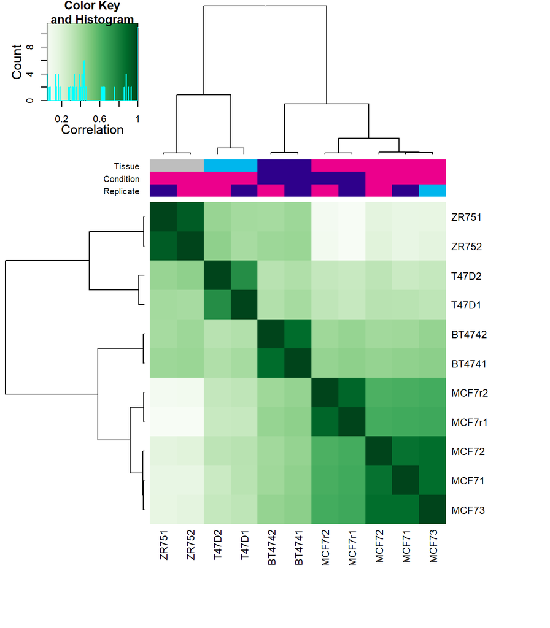

Figure 2: Correlation heatmap

```r
# dir.create(here("results/plots"),showWarnings = F)
setEPS()
postscript(here("results/plots/Fig2.eps"))
plot(tamoxifen)
invisible(capture.output(dev.off()))
plot(tamoxifen)
```

## 4.3 Normalization

One important step in differential peak analysis is normalization. We need to normalize our data because it contains noise and technical biases on top of actual biological signal. We do not know which of our data is noise or bias, therefore, we need to consider various normalization strategies to select a proper one, which does not remove or alter actual biological effects.

### 4.3.1 Sample normalization methods

`DiffBind` has three different sample normalization methods. One is native to `DESeq2`, another one to `edgeR` (both are differential analysis packages for RNA-Seq data) and the third one is a simple method, which normalizes by library size. It has to be noted here that `DESeq2` and `edgeR` are designed for RNA-Seq data, which fulfills different assumptions than we would expect for most ChIP-Seq data. In RNA-Seq, for example, we assume that most of the genes are not differentially expressed and that they have the same basal expression across samples. The influence of differentially expressed genes to the normalization are negligible since it is assumed that the great majority of the genes are not differentially expressed. For ChIP-Seq data, however, this assumption might not be true. Due to the fact that we enrich for our regions of interest, we likely have big differences in reads numbers per peak across different samples. A normalization with `DESeq2` or `edgeR` should therefore be avoided if you expect a considerable difference between your conditions.

- `"lib"`: makes all libraries equal size
- `"RLE"`: native to [DESeq2](http://bioconductor.org/packages/release/bioc/html/DESeq2.html), calculates geometric mean for each peak across samples
- `"TMM"`: native to [edgeR](http://bioconductor.org/packages/release/bioc/html/edgeR.html), calculates a trimmed mean of M-values

### 4.3.2 Library size

One technical bias that always influences our data is sequencing depth. Samples which were sequenced deeper will statistically have more reads within a peak than samples with a shallower sequencing depth. When we normalize by library size, we can either normalize by all aligned reads, which would be the `full` set of reads or we could focus on the reads in peaks (`RiP`), which not only take into account the sequencing depth but also the ChIP efficiency. Normalizing by full library size is a safe choice for normalization because we do not make any assumptions about our data such as that the majority of the peaks are not different across samples (as would be expected for RNA-Seq data). Therefore, we do not risk to accidentally remove true biological signal with this method. Normalization by reads in peaks, on the other hand, is only an option if you expect to see no differences between the conditions for the majority of your peaks. In this case, however, a RLE or TMM normalization may be a better choice.

- `"full"`: uses all aligned reads; no assumptions made
- `"RiP"`: uses only reads aligned to consensus peakset; takes into account sequencing depth and ChIP efficiency

### 4.3.3 Background normalization

Instead of focusing on the reads in peaks, as is done for the native normalization techniques of DESeq2 and edgeR, one could also normalize for differences across the background. The background signal is estimated based on large bins of the genome which should be large enough to stretch well over enriched regions. Therefore, the median signal at large intervals should represent background noise only. We expect that our ChIP-Seq enrichment occurs over narrow intervals of not more than 600 bp. Therefore, we set our background bin size to a considerable larger window of 10 kbp to estimate the median average background signal. This normalization has the benefit that the normalization factors will most likely not be influenced by imbalanced conditions. This normalization approach is based on an algorithm of [csaw](https://bioconductor.org/packages/release/bioc/html/csaw.html), a differential ChIP-Seq tool that does not rely on previously called peaks, but uses sliding windows.

### 4.3.4 Normalization conclusion

Selecting the correct normalization for your data is not trivial for ChIP-Seq data and often requires some experience as well as in-depth knowledge about the data. The safest option, which does not make assumptions about the data distribution, is doing a normalization by library size. This is also the default if you use `dba.normalize()` without setting additional parameters. Furthermore, applying the DESeq2 or edgeR normalization methods to background reads rather than the RiP, can be a good choice, as it has the benefit to remove technical biases in addition to differences in sequencing depth with a low risk to alter true biological differences between samples. Please note that the background normalization depends on the usage of very large genomic bins, which are expected to have non-extreme median values. Therefore, this method is not appropriate for very broad chromatin profiles.

### 4.3.5 Example normalization

In our case, we will apply the standard normalization (`normalize = lib`) with background normalization using the `dba.normalize` function. Here, we assume that a background window of at least 10.000 bases (`background = 10000`) will be large enough to even out peaks within that window when estimating sample specific background signals.

```r
tamoxifen <- dba.normalize(tamoxifen, background = 10000, normalize = DBA_NORM_LIB)
tamoxifen
```

```
## 11 Samples, 2683 sites in matrix:
##        ID Tissue Factor  Condition  Treatment Replicate   Reads FRiP
## 1  BT4741  BT474     ER  Resistant Full-Media         1  652697 0.15
## 2  BT4742  BT474     ER  Resistant Full-Media         2  663370 0.14
## 3   MCF71   MCF7     ER Responsive Full-Media         1  346429 0.29
## 4   MCF72   MCF7     ER Responsive Full-Media         2  368052 0.17
## 5   MCF73   MCF7     ER Responsive Full-Media         3  466273 0.23
## 6   T47D1   T47D     ER Responsive Full-Media         1  399879 0.09
## 7   T47D2   T47D     ER Responsive Full-Media         2 1475415 0.05
## 8  MCF7r1   MCF7     ER  Resistant Full-Media         1  616630 0.19
## 9  MCF7r2   MCF7     ER  Resistant Full-Media         2  593224 0.12
## 10  ZR751   ZR75     ER Responsive Full-Media         1  706836 0.29
## 11  ZR752   ZR75     ER Responsive Full-Media         2 2575408 0.19
```

## 4.4 Defining contrasts

In the next step, we need to supply `DiffBind` with information about the experimental design for it to work with the correct model for the data. A simple design would include two conditions, e.g. treatment and control, without considering any other factors that may have influenced the outcome. However, real experiments are often more complex than that. Due to the wide range of possible experimental designs, we will not discuss this topic in detail. Instead, we commend the following resources: The [DESeq2 vignette](http://bioconductor.org/packages/release/bioc/vignettes/DESeq2/inst/doc/DESeq2.html#the-deseq2-model) explains in detail different experimental designs. If you are unsure which design applies to your experiment, you can also have a look at [this guide](https://bioconductor.org/packages/release/workflows/vignettes/RNAseq123/inst/doc/designmatrices.html), which gives instructions on how to create design matrices for gene expression experiments. This guide is written for another R package called `limma`, however, the design formulas you find there can also be used for the `dba.contrast()` function as shown below. If you are still uncertain about which design model is suitable for your experiment, you can also consult a statistician.

In case of our exemplary data set, we want to compare between the conditions ‘resistant’ and ‘responsive’. To add these contrasts to our dba object, we use `dba.contrast()`. The additional parameter `reorderMeta=list(Condition='Responsive')` makes sure that we compare the resistant group to the responsive group. Therefore, all positive fold changes (FC) will represent an enrichment in the resistant group in comparison to the responsive group and negative FCs show decreased signal in the resistant group and an increase in the responsive group.

```r
tamoxifen <- dba.contrast(tamoxifen, reorderMeta = list(Condition = "Responsive"), design = "~ Condition")
tamoxifen
```

```
## 11 Samples, 2683 sites in matrix:
##        ID Tissue Factor  Condition  Treatment Replicate   Reads FRiP
## 1  BT4741  BT474     ER  Resistant Full-Media         1  652697 0.15
## 2  BT4742  BT474     ER  Resistant Full-Media         2  663370 0.14
## 3   MCF71   MCF7     ER Responsive Full-Media         1  346429 0.29
## 4   MCF72   MCF7     ER Responsive Full-Media         2  368052 0.17
## 5   MCF73   MCF7     ER Responsive Full-Media         3  466273 0.23
## 6   T47D1   T47D     ER Responsive Full-Media         1  399879 0.09
## 7   T47D2   T47D     ER Responsive Full-Media         2 1475415 0.05
## 8  MCF7r1   MCF7     ER  Resistant Full-Media         1  616630 0.19
## 9  MCF7r2   MCF7     ER  Resistant Full-Media         2  593224 0.12
## 10  ZR751   ZR75     ER Responsive Full-Media         1  706836 0.29
## 11  ZR752   ZR75     ER Responsive Full-Media         2 2575408 0.19
##
## Design: [~ Condition]
```

## 4.5 Differential peak analysis

The actual differential analysis of `DiffBind` can be performed with `dba.analyze()`. Per default, the `DESeq2` method is used for for this. Optionally, you can also change this to `DBA_EDGER`to use the `edgeR` method or `DBA_ALL_METHODS` to perform two analyses with both methods. DESeq2 uses a negative binomial distribution to model the data and estimates the distribution’s parameters using a maximum likelihood estimation. Subsequently, a Wald test is performed to test for differential enrichment (this gives us the p-values). Lastly, a Benjamini-Hochberg procedure is used to control the false discovery rate (FDR) in multiple testing situations.

```r
tamoxifen <- dba.analyze(tamoxifen, method = DBA_DESEQ2, bBlacklist = DBA_BLACKLIST_GRCH38, bGreylist = FALSE)
dba.show(tamoxifen, bContrasts = TRUE)
```

```
##      Factor     Group Samples     Group2 Samples2 DB.DESeq2
## 1 Condition Resistant       4 Responsive        7       397
```

We can use `dba.show()` with `bContrasts = TRUE` to check that we have made the appropriate comparison. We can see that group 1 represents the condition that we are interested in, which is the resistant group and consists of 4 samples. Group 2 is the responsive condition, which consists of 7 samples and serves as a baseline. ‘DB.DESeq2’ shows the number of differential peaks, which were identified with the DESeq2 method. Usually, we would expect to find a lot more peaks (hundreds or thousands), however, this dataset includes only reads, which were aligned to chromosome 18 to reduce the computational effort in this example analysis.

## 4.6 Split analysis in multiple steps

Please note that we can combine all the last steps in one piece of code in which the output of the previous function is piped into the next function. This way, you can apply all steps at once. However, if your new to `DiffBind`, we recommend to run the analysis step by step and investigate intermediate data to properly understand what each step is doing.

```r
# This would be the whole analysis in one command
tamoxifen <- dba(sampleSheet = here("DiffBind_Vignette", "tamoxifen.csv")) %>%
  dba.blacklist(blacklist = DBA_BLACKLIST_HG38, greylist = FALSE) %>%
  dba.count() %>%
  dba.normalize(background = 10000, normalize = DBA_NORM_LIB) %>%
  dba.contrast(reorderMeta = list(Condition = "Responsive"), design = "~ Condition")  %>%
  dba.analyze(method = DBA_DESEQ2, bBlacklist = DBA_BLACKLIST_GRCH38, bGreylist = FALSE)
```

## 4.7 Report the results

We can export all the data of our differential peaks to a file by using `dba.report()`. It will generate a `GRanges` object that contains info about all our significant differential peaks. Per default, differential peaks are only filtered by FDR with this function. We recommend to apply an additional filter based on a minimum absolute fold change with the `fold` option (e.g `fold = 1`). `GRanges` objects behave similarly to data frames, therefore, we can use `write.csv()` to extract our data about differential binding in a comma separated file. To include all peak information, regardless of filtering based on log2 fold change and significance, use `dba.report()` with a threshold of 1 (`th = 1`). Additionally, you can export the positions of the differential peaks also in a bed format, which is often needed for certain downstream analyses. In order to get a bed file, we need to use the `export()` function of the `rtracklayer` package.

```r
tamoxifen.DB <- dba.report(tamoxifen, fold = 1)
tamoxifen.DB
```

```
## GRanges object with 40 ranges and 6 metadata columns:
##        seqnames            ranges strand |      Conc Conc_Resistant
##           <Rle>         <IRanges>  <Rle> | <numeric>      <numeric>
##   2409    chr18 69433158-69433558      * |   5.24751        0.00000
##    339    chr18   9785248-9785648      * |   6.17640        1.09140
##    815    chr18 26861047-26861447      * |   8.35407        4.06350
##   1130    chr18 34597763-34598163      * |   6.24777        1.17212
##   2177    chr18 60892950-60893350      * |   8.06542        2.81959
##    ...      ...               ...    ... .       ...            ...
##   1068    chr18 33103346-33103746      * |   3.57979       0.000000
##    329    chr18   9717592-9717992      * |   5.33211       2.395447
##   2289    chr18 64488772-64489172      * |   5.28504       0.428156
##    866    chr18 28847806-28848206      * |   2.86834       0.000000
##   2213    chr18 61835727-61836127      * |   5.70669       0.624310
##        Conc_Responsive      Fold     p-value        FDR
##              <numeric> <numeric>   <numeric>  <numeric>
##   2409         5.89959  -5.27215 7.48184e-07 0.00170575
##    339         6.81294  -4.55493 1.80503e-06 0.00170575
##    815         8.97909  -4.18557 1.90728e-06 0.00170575
##   1130         6.88420  -4.51250 3.50249e-06 0.00173397
##   2177         8.70360  -4.56747 3.76383e-06 0.00173397
##    ...             ...       ...         ...        ...
##   1068         4.21689  -3.80891 0.000559088  0.0416251
##    329         5.91398  -3.06388 0.000584816  0.0416251
##   2289         5.91890  -3.78557 0.000589547  0.0416251
##    866         3.52042  -3.76206 0.000712744  0.0486398
##   2213         6.34320  -3.76533 0.000725155  0.0486398
##   -------
##   seqinfo: 1 sequence from an unspecified genome; no seqlengths
```

```r
dir.create(here("results"),showWarnings = F)
write.csv(dba.report(tamoxifen, th = 1), here("results", "differential_binding.csv"), row.names = FALSE, quote = FALSE)

library(rtracklayer)
export(tamoxifen.DB, here("results", "differential_binding.bed"))
```

# 5 Visualization of results

DiffBind offers many easy-to-use functions to visualize results of the differential analysis. We will explain a selection of them, which are important to communicate the findings.

## 5.1 Volcano plots

A very popular visualization strategy for differential data are volcano plots, which can be generated with `dba.plotVolcano()` (see Figure 3). They are simple scatter plots which show the log2 fold-change of the peaks on the x-axis and the negative decadent logarithm of the false discovery rate (FDR) on the y-axis. All dots in pink are significantly differentially enriched in one of the conditions.

```r
# dba.plotVolcano(tamoxifen)

## Plot function exported and adapted from diffbind package
## see getAnywhere(dba.plotVolcano), getAnywhere(pv.DBAplotVolcano)
plotVolcano=function (pv, contrast, method = "DESeq2", th = 0.05, bUsePval = FALSE,
    fold = 0, facname = "", bLabels = FALSE, maxLabels = 50,
    dotSize = 1, bSignificant = TRUE, bFlip = FALSE, xrange,
    yrange)
{
    if (missing(contrast)) {
        contrast <- 1:length(pv$contrasts)
    }
    else {
        if (contrast > length(pv$contrasts)) {
            stop("Specified contrast number is greater than number of contrasts",
                call. = FALSE)
            return(NULL)
        }
    }
    for (con in 1:length(contrast)) {
        conrec <- pv$contrasts[[contrast[con]]]
        name1 <- conrec$name1
        name2 <- conrec$name2
        if (bFlip) {
            name1 <- conrec$name2
            name2 <- conrec$name1
        }
        for (meth in method) {
            res <- DiffBind:::pv.DBAreport(pv, contrast = contrast[con],
                method = meth, bUsePval = TRUE, th = 100, bNormalized = TRUE,
                bFlip = bFlip, precision = 0, lfc = fold)
            if (!is.null(res)) {
                if (bUsePval) {
                  vals <- res$"p-value"
                  idx <- vals <= th
                  tstr <- "p"
                  res = mutate(res, Legend = ifelse(res$"p-value" <=
                    th, sprintf(" p-val<=%1.2f", th), sprintf(" p-val >%1.2f",
                    th)))
                }
                else {
                  vals <- res$FDR
                  idx <- vals <= th
                  tstr <- "FDR"
                  res = mutate(res, Legend = ifelse(res$FDR <
                    th, sprintf(" FDR<=%1.2f", th), sprintf(" FDR >%1.2f",
                    th)))
                }
                res$Legend[idx & abs(res$Fold) < fold] <- sprintf("abs(Fold)<%1.2f",
                  2^fold)
                idx <- idx & abs(res$Fold) >= fold
                sigSites <- res[idx, ]
                if (sum(idx) > 0) {
                  rownames(sigSites) <- 1:sum(idx)
                }
                res <- cbind(0, res)
                colnames(res)[1] <- "SiteNum"
                if (sum(idx) > 0) {
                  res[idx, 1] <- 1:sum(idx)
                  sidx <- sum(idx)
                }
                else {
                  sidx <- 0
                }
                constr <- DiffBind:::pv.getContrastString(conrec, bFlip)
                plotTitle <- sprintf("%s Contrast: %s  [%s %s<=%1.3f",
                  facname, constr, sidx, tstr, th)
                if (fold > 0) {
                  plotTitle <- sprintf("%s & abs(Fold)>=%1.2f]",
                    plotTitle, 2^fold)
                }
                else {
                  plotTitle <- sprintf("%s]", plotTitle)
                }
                xLabel <- "log2 Fold Change"
                yLabel <- sprintf("-log10(%s)", tstr)
                p <- ggplot(res, aes(Fold, -log10(vals))) + geom_point(aes(col = Legend),
                  size = dotSize) + scale_color_manual(values = c("#648FFF","#DC267F","gray"
                  )) + labs(title = plotTitle,
                  x = xLabel, y = yLabel) + theme_minimal()
                if (bLabels) {
                  maxLabels <- min(sidx, maxLabels)
                  if (maxLabels > 0 && sidx > 0) {
                    xx <- which(idx)[1:maxLabels]
                    p <- p + geom_text_repel(data = sigSites[1:maxLabels,
                      ], aes(x = Fold, y = -log10(vals[xx]),
                      label = rownames(sigSites)[1:maxLabels]))
                  }
                }
                plot(p)
            }
        }
    }
    #if (sidx > 0) {
    #    return(sigSites[, -10])
    #}
    #else {
    #    return(NULL)
    #}
}
```

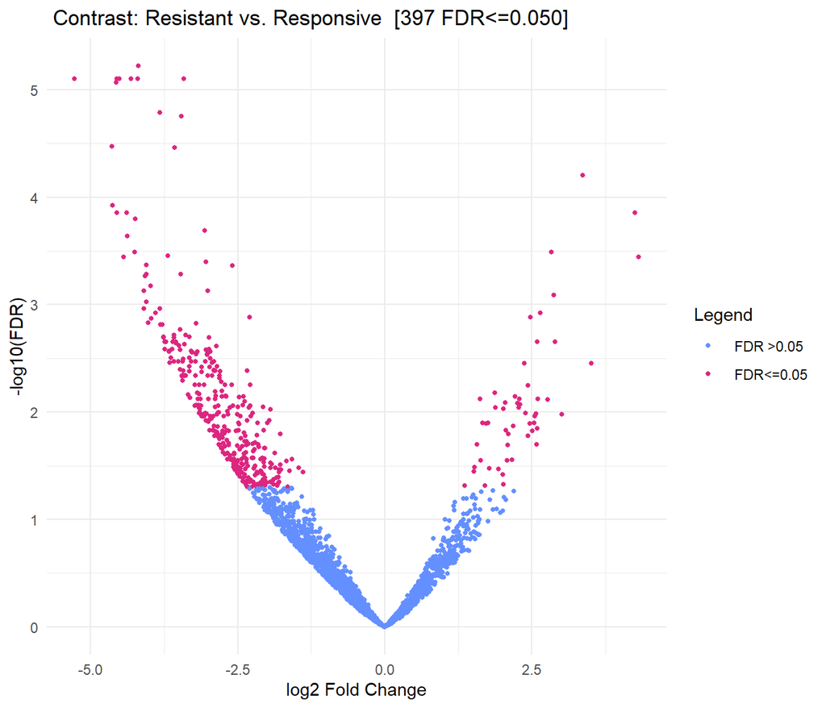

Figure 3: Volcano plot

```r
# save the plot
setEPS()
postscript(here("results", "plots", "Fig3.eps"), height=5, width=6.5)
plotVolcano(tamoxifen)
invisible(capture.output(dev.off()))
# plot
plotVolcano(tamoxifen)
```

### 5.1.1 MA plots

We can also visualize our results in a MA plot with the `dba.plotMA()`function (see Figure 4.1 and 4.2). MA plots are a common visualization method for differential data. It was originally designed for microarray data in which M-values were plotted against A-values, hence, the name of the plot. In our case, the x-axis represents the log concentration (A-value) of our peaks, also known as the mean normalized read number per peak. On the y-axis we can see the log2 fold-change (M-value) between our conditions. Each dot represents a peak. All peaks that are more enriched in the control group (in our case the responsive group) are plotted below the blue line in the middle. Peaks which are more enriched in the resistant group, are above the blue line. Significant differential peaks are marked in pink. Furthermore, we can see a blue cloud in the background which is a smoothed representation of our non-differential peaks. The darker the cloud, the more peaks can be found in that area of the plot. You can use the `bSmooth=FALSE` option to plot the actual non-differential peaks instead of using the smoothed representation.

Moreover, you can see a red line within the plot. This is a fitted Loess curve, which shows local differences in mean values. Ideally, this line should be more or less straight. Deviations from this highlight local biases in our data that might need to be removed. Furthermore, if this red line is clearly above or below the blue line, our data is unbalanced and we have more differential binding in one of our conditions. Due to this property, we can use MA plots to make decisions about our normalization strategy. Note that you still need to apply `dba.contrast()` and `dba.analyze()` on the non-normalized data to make MA plots.

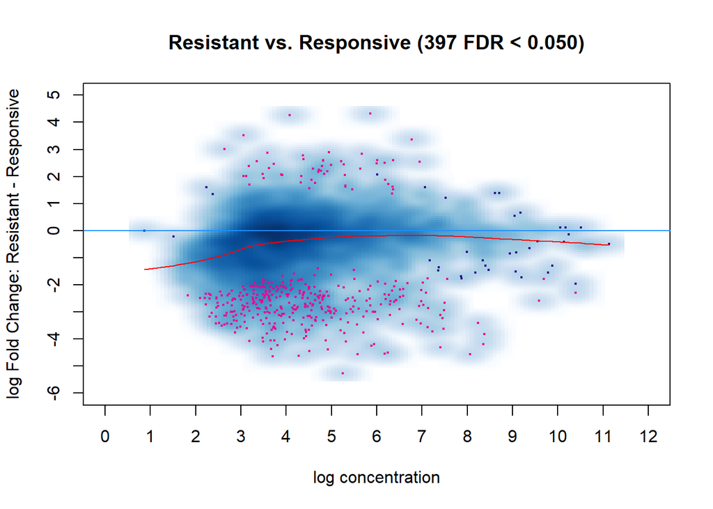

Figure 4.1: MA plot with density cloud

```r
dba.plotMA(tamoxifen)
```

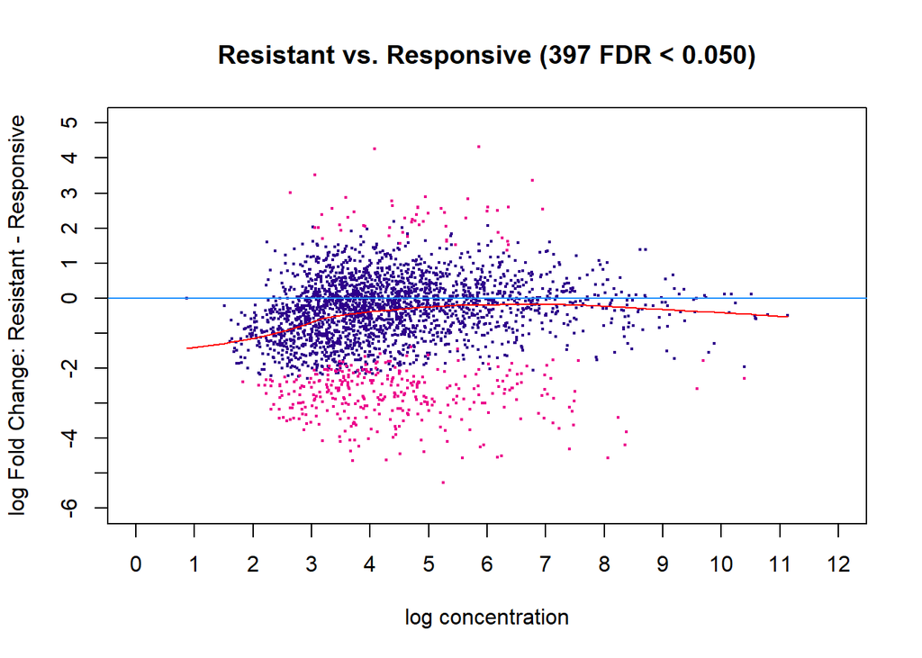

Figure 4.2: MA plot w/o density cloud

```r
dba.plotMA(tamoxifen, bSmooth = FALSE)
```

```r
# save the plots
setEPS()
postscript(here("results", "plots", "Fig4-1.eps"))
dba.plotMA(tamoxifen)
invisible(capture.output(dev.off()))

setEPS()
postscript(here("results", "plots", "Fig4-2.eps"))
dba.plotMA(tamoxifen, bSmooth = FALSE)
invisible(capture.output(dev.off()))
```

In our case, the MA plot looks balanced, however with more differential peaks showing negative log fold changes, indicating more reduced binding events in the resistant group.

## 5.2 Save the dba object

Here, we save the dba object using the function `dba.save()` to the file `ER_analysis_dba.RData`.

# 6 Downstream Analysis

Now that we have identified differential peaks, we can ask more in-depth question about the functional background of these peaks. For example, transcription factors and certain histone modifications are linked to gene regulation and their ChIP-Seq peaks can be associated with the genes they may regulate. Furthermore, we can extract the sequences of the peaks and investigate them for the presence of recurring motifs. Furthermore, we can visualize BAM, BED or signal tracks from ChIP-Seq datasets in a genome browser.

## 6.1 Peak annotation: linking peaks to genes

Due to the fact that in these experiments, estrogen receptor alpha was immunoprecipitated, which acts like a transcription factor upon ligand binding, we can assume that our differential peaks are associated with gene regulation. A simple approach to connect differential peaks with its regulated genes is looking for overlaps of our peaks with promoters of known genes.

We can use available libraries such as `TxDb.Hsapiens.UCSC.hg38.knownGene` to load annotated genome regions for our genome of interest, which is the homo sapiens genome hg38 from UCSC. This data is loaded as a `GRanges` object, which are the common data type for `GenomicRanges`. This package can handle and manipulate genomic annotations. A simple GRanges object consists of the genomic positions in specific format, which includes the sequence name, the start and the end position. Additional columns can be added, which provide the genomic positions with context (e.g. names, scores, …). We can extract genes from this dataset by using `genes()` and take windows around their TSS with `promoters()` to specify regions in which we expect to find the promoter. We use the `promoters()`function to extract the position of the transcriptional start sites (TSS). These are then used to define regulatory domains for each gene by creating basal windows 5000 bp upstream an 1000 bp downstream of the TSS. Furthermore, the regulatory domain will be extended to the basal regulatory domain of the next gene by maximum 1 Mbp. Eventually, we can use `findOverlaps()` with the GRanges object of our differential peaks and the defined regulatory domains. At this point, the genes are specified by a Entrez gene identifiers. To retrieve the respective gene symbols for further analyses and interpretations, we use biomaRt to convert the ids to gene names. Eventually, we combine the collected gene info with the results of the differential analysis and export them in a csv file (see also Table 4).

```r
# load the genome database and extract the transcriptional start sites for all genes
txdb <- TxDb.Hsapiens.UCSC.hg38.knownGene
suppressMessages(genes_gr <- genes(txdb))
tss_gr <- promoters(genes_gr, 0,1)

# define regulatory domains for each gene
etss <- extendTSS(tss_gr, genome = "hg38", gene_id_type = "ENTREZ", basal_upstream = 5000, basal_downstream = 1000, extension = 1000000)
```

```
## * use genome 'hg38'.
```

```
## * TSS extension mode is 'basalPlusExt'.
```

```
## * construct the basal domains by extending 5000bp to upstream and 1000bp to downsteram of TSS.
```

```
## * calculate distances to neighbour regions.
```

```
## * extend to both sides until reaching the neighbour genes or to the maximal extension (1000000bp).
```

```r
# find overlaps of the differential peaks with regulatory domains of genes
basal_ext <- findOverlaps(tamoxifen.DB, etss, type='any', ignore.strand=TRUE)
basal_ext_gr <- tamoxifen.DB[queryHits(basal_ext)]
basal_ext_gr$gene_id <- etss[subjectHits(basal_ext)]$gene_id

# convert entrezgene ids to gene symbols and ensembl gene ids
tryCatch({
# Update timeout for downloads
options(timeout = max(30000, getOption("timeout")))
mart <- useEnsembl(biomart = "genes", dataset = "hsapiens_gene_ensembl", mirror = "useast")
res_basal <- getBM(attributes = c('entrezgene_id', 'ensembl_gene_id', 'external_gene_name'),
      filters = 'entrezgene_id',
      values = basal_ext_gr$gene_id,
      mart = mart)

# merge the gene info with the differential peaks list
basal_ext_res <- merge(as.data.frame(basal_ext_gr, row.names = NULL), res_basal, by.x="gene_id", by.y="entrezgene_id", all.x=T, all.y=T)
basal_ext_res <- unique(basal_ext_res)

# save the data in a csv table
write.csv(basal_ext_res, here("results", "gene_annotations.csv"), row.names = FALSE, quote = FALSE)

#kable(basal_ext_res, caption = 'Overlap of differential peaks with regulatory domains of genes')
library(DT)
datatable(basal_ext_res, extensions = c('Buttons'), options = list(dom = 'Bfrtip', buttons = c('csv', 'excel'), autoWidth = TRUE, scrollX = TRUE), caption = htmltools::tags$caption(
    style = 'caption-side: top; text-align: left;',
    'Table 4 ', htmltools::em('Overlap of differential peaks with regulatory domains of genes')))
},
error = function(e) {
  str(e) # prints error
}
)
```

[output not shown]

|  | gene_id | seqnames | start | end | width | strand | Conc | Conc_Resistant | Conc_Responsive | Fold | p.value | FDR | ensembl_gene_id | external_gene_name |
| --- | --- | --- | --- | --- | --- | --- | --- | --- | --- | --- | --- | --- | --- | --- |
| 1 | 1000 | chr18 | 28847806 | 28848206 | 401 | * | 2.868338442953989 | 0 | 3.520415139533682 | -3.762063370020995 | 0.0007127443948234695 | 0.04863976732954583 | ENSG00000170558 | CDH2 |
| 2 | 100128893 | chr18 | 22569798 | 22570198 | 401 | * | 3.669942984756074 | 0 | 4.322019681335767 | -4.376385710442476 | 5.346187984827602e-05 | 0.00888554965317738 | ENSG00000266010 | GATA6-AS1 |
| 3 | 100192426 | chr18 | 8371300 | 8371700 | 401 | * | 3.971872927236118 | 0 | 4.623949623815811 | -4.024802861181705 | 0.0003248114835855848 | 0.02811191001484271 | ENSG00000266149 |  |
| 4 | 100287082 | chr18 | 8732623 | 8733023 | 401 | * | 5.856992724424011 | 7.289600950493468 | 0.7465476596541682 | 4.315374579805718 | 8.200724277814523e-05 | 0.010717508287804 | ENSG00000265962 | GACAT2 |
| 5 | 100505592 | chr18 | 3446516 | 3446916 | 401 | * | 5.199034005990268 | 1.157563976595096 | 5.818894215649262 | -3.69213116974327 | 0.000246066577116315 | 0.02256291293489787 |  |  |
| 6 | 100616290 | chr18 | 55580929 | 55581329 | 401 | * | 5.881593881063091 | 0.3891294139951293 | 6.521970056543754 | -4.252268087915837 | 8.388657250983375e-05 | 0.010717508287804 | ENSG00000264571 | MIR4529 |
| 7 | 100616290 | chr18 | 55569137 | 55569537 | 401 | * | 6.570802355267984 | 3.232400960212151 | 7.170057758916032 | -3.454121204430135 | 5.630053824227189e-05 | 0.00888554965317738 | ENSG00000264571 | MIR4529 |
| 8 | 100996669 | chr18 | 61835727 | 61836127 | 401 | * | 5.706688976584463 | 0.6243102240983057 | 6.343197612660871 | -3.765331584529882 | 0.0007251549359604298 | 0.04863976732954583 |  |  |
| 9 | 101927168 | chr18 | 6731169 | 6731569 | 401 | * | 4.08431359227267 | 5.501314227726561 | 0 | 4.257738175057463 | 4.498439255550872e-05 | 0.008620937516173564 |  |  |
| 10 | 101927404 | chr18 | 64490736 | 64491136 | 401 | * | 7.402314582154784 | 2.769306851085932 | 8.033091774323104 | -4.314301641221387 | 3.877691630424204e-06 | 0.001733974440738023 |  |  |

[output cut: 66 more lines]

You can extract the gene names from the list and use them as input for pathway enrichment analysis web-tools like [Enrichr](https://maayanlab.cloud/Enrichr/), [DAVID](https://david.ncifcrf.gov/tools.jsp) and [WEBGESTALT](http://www.webgestalt.org) and a myriad of R tools such as [clusterProfiler](https://bioconductor.org/packages/release/bioc/html/clusterProfiler.html) or [topGO](https://bioconductor.org/packages/release/bioc/html/topGO.html).

## 6.2 Motif discovery

Moreover, you can perform motif analysis. Therefore, you have to extract the sequences from the differential regions to a fasta file. First load the `BSgenome.Hsapiens.UCSC.hg38` library and extract the subsequences of the genome with `getSeq()`. Then specify the names of the sequences and save the sequences to a fasta file with `writeXStringSet()` from the `Biostrings` package. The sequences are saved to `results/significant_regions.fa`.  
You can then use the [MEME server](https://meme-suite.org) to find recurring motifs in these sequences.

```r
seq <- getSeq(BSgenome.Hsapiens.UCSC.hg38, tamoxifen.DB)
names(seq) <- as.character(tamoxifen.DB)
writeXStringSet(seq, here('results', 'significant_regions.fa'), format = 'fasta')
```

## 6.3 Visualization in genome browsers

Various ChIP-Seq files can be visualized in a genome browser such as the [integrative genome viewer (IGV)](https://igv.org/app/). For example, you can load the BED files of the individual samples, as well as their consensus peak set BED file in IGV. Furthermore you can depict differences in the ChIP-Seq signal of differential peaks by loading in the bedgraph files from the nf-core chipseq pipeline, which can be found at `results/bwa/mergedLibrary/bigwig`.

# 7 Session Info

```r
sessionInfo()
## R version 4.2.2 (2022-10-31 ucrt)
## Platform: x86_64-w64-mingw32/x64 (64-bit)
## Running under: Windows 10 x64 (build 19045)
##
## Matrix products: default
##
## locale:
## [1] LC_COLLATE=English_United States.utf8
## [2] LC_CTYPE=English_United States.utf8
## [3] LC_MONETARY=English_United States.utf8
## [4] LC_NUMERIC=C
## [5] LC_TIME=English_United States.utf8
##
## attached base packages:
## [1] stats4    stats     graphics  grDevices utils     datasets  methods
## [8] base
##
## other attached packages:
##  [1] BSgenome.Hsapiens.UCSC.hg38_1.4.5
##  [2] BSgenome_1.66.3
##  [3] Biostrings_2.66.0
##  [4] XVector_0.38.0
##  [5] TxDb.Hsapiens.UCSC.hg38.knownGene_3.16.0
##  [6] GenomicFeatures_1.50.4
##  [7] AnnotationDbi_1.60.2
##  [8] biomaRt_2.54.1
##  [9] rGREAT_2.0.2
## [10] rtracklayer_1.58.0
## [11] ggplot2_3.4.2
## [12] dplyr_1.1.2
## [13] DiffBind_3.8.4
## [14] SummarizedExperiment_1.28.0
## [15] Biobase_2.58.0
## [16] MatrixGenerics_1.10.0
## [17] matrixStats_1.0.0
## [18] GenomicRanges_1.50.2
## [19] GenomeInfoDb_1.34.9
## [20] IRanges_2.32.0
## [21] S4Vectors_0.36.2
## [22] BiocGenerics_0.44.0
## [23] DT_0.27
## [24] here_1.0.1
##
## loaded via a namespace (and not attached):
##   [1] circlize_0.4.15
##   [2] snow_0.4-4
##   [3] BiocFileCache_2.6.1
##   [4] plyr_1.8.9
##   [5] BiocParallel_1.32.6
##   [6] crosstalk_1.2.0
##   [7] amap_0.8-19
##   [8] digest_0.6.31
##   [9] foreach_1.5.2
##  [10] invgamma_1.1
##  [11] htmltools_0.5.5
##  [12] GO.db_3.16.0
##  [13] SQUAREM_2021.1
##  [14] fansi_1.0.4
##  [15] csaw_1.32.0
##  [16] magrittr_2.0.3
##  [17] memoise_2.0.1
##  [18] doParallel_1.0.17
##  [19] limma_3.54.2
##  [20] annotate_1.76.0
##  [21] systemPipeR_2.4.0
##  [22] bdsmatrix_1.3-6
##  [23] prettyunits_1.1.1
##  [24] jpeg_0.1-10
##  [25] colorspace_2.1-0
##  [26] rappdirs_0.3.3
##  [27] blob_1.2.4
##  [28] apeglm_1.20.0
##  [29] ggrepel_0.9.4
##  [30] xfun_0.39
##  [31] crayon_1.5.2
##  [32] RCurl_1.98-1.12
##  [33] jsonlite_1.8.5
##  [34] TxDb.Hsapiens.UCSC.hg19.knownGene_3.2.2
##  [35] iterators_1.0.14
##  [36] glue_1.6.2
##  [37] gtable_0.3.3
##  [38] zlibbioc_1.44.0
##  [39] GetoptLong_1.0.5
##  [40] DelayedArray_0.23.2
##  [41] shape_1.4.6
##  [42] scales_1.2.1
##  [43] mvtnorm_1.2-3
##  [44] DBI_1.1.3
##  [45] edgeR_3.40.2
##  [46] Rcpp_1.0.10
##  [47] xtable_1.8-4
##  [48] progress_1.2.2
##  [49] emdbook_1.3.13
##  [50] bit_4.0.5
##  [51] truncnorm_1.0-9
##  [52] metapod_1.6.0
##  [53] htmlwidgets_1.6.1
##  [54] httr_1.4.6
##  [55] gplots_3.1.3
##  [56] RColorBrewer_1.1-3
##  [57] ellipsis_0.3.2
##  [58] pkgconfig_2.0.3
##  [59] XML_3.99-0.14
##  [60] farver_2.1.1
##  [61] dbplyr_2.3.2
##  [62] sass_0.4.6
##  [63] deldir_1.0-9
##  [64] locfit_1.5-9.8
##  [65] utf8_1.2.3
##  [66] later_1.3.0
##  [67] tidyselect_1.2.0
##  [68] labeling_0.4.2
##  [69] rlang_1.1.1
##  [70] munsell_0.5.0
##  [71] tools_4.2.2
##  [72] cachem_1.0.8
##  [73] cli_3.6.1
##  [74] generics_0.1.3
##  [75] RSQLite_2.3.1
##  [76] evaluate_0.21
##  [77] stringr_1.5.0
##  [78] fastmap_1.1.1
##  [79] yaml_2.3.7
##  [80] org.Hs.eg.db_3.16.0
##  [81] knitr_1.43
##  [82] bit64_4.0.5
##  [83] caTools_1.18.2
##  [84] purrr_1.0.1
##  [85] KEGGREST_1.38.0
##  [86] mime_0.12
##  [87] xml2_1.3.4
##  [88] compiler_4.2.2
##  [89] rstudioapi_0.14
##  [90] filelock_1.0.2
##  [91] curl_5.0.1
##  [92] png_0.1-8
##  [93] tibble_3.2.1
##  [94] geneplotter_1.76.0
##  [95] bslib_0.5.0
##  [96] stringi_1.7.12
##  [97] highr_0.10
##  [98] lattice_0.20-45
##  [99] Matrix_1.5-1
## [100] vctrs_0.6.3
## [101] pillar_1.9.0
## [102] lifecycle_1.0.3
## [103] GlobalOptions_0.1.2
## [104] jquerylib_0.1.4
## [105] bitops_1.0-7
## [106] irlba_2.3.5.1
## [107] httpuv_1.6.9
## [108] R6_2.5.1
## [109] BiocIO_1.8.0
## [110] latticeExtra_0.6-30
## [111] hwriter_1.3.2.1
## [112] promises_1.2.0.1
## [113] ShortRead_1.56.1
## [114] KernSmooth_2.23-20
## [115] codetools_0.2-18
## [116] MASS_7.3-58.1
## [117] gtools_3.9.4
## [118] DESeq2_1.38.3
## [119] rprojroot_2.0.3
## [120] rjson_0.2.21
## [121] withr_2.5.0
## [122] GenomicAlignments_1.34.1
## [123] Rsamtools_2.14.0
## [124] GenomeInfoDbData_1.2.9
## [125] parallel_4.2.2
## [126] hms_1.1.3
## [127] grid_4.2.2
## [128] coda_0.19-4
## [129] rmarkdown_2.22
## [130] GreyListChIP_1.30.0
## [131] ashr_2.2-63
## [132] mixsqp_0.3-48
## [133] bbmle_1.0.25
## [134] shiny_1.7.4
## [135] numDeriv_2016.8-1.1
## [136] interp_1.1-4
## [137] restfulr_0.0.15
```